# temp-161557887641316661

𝕊𝕒𝕝𝕒𝕞. 𝕂𝕠𝕞𝕒𝕟𝕕𝕒𝕞ı𝕫ı𝕟 ü𝕫𝕧𝕝ə𝕣𝕚 𝕒ş𝕒ğı𝕕𝕒𝕜𝕚𝕝ə𝕣𝕕𝕚𝕣.

**𝟙. 𝔾ü𝕟𝕖𝕝 𝔸ğ𝕒𝕜𝕚ş𝕚𝕪𝕖𝕧𝕒 𝟚. 𝕄ə𝕙ə𝕞𝕞ə𝕕 ℕə𝕓𝕚𝕫𝕒𝕕ə 𝟛. ℤ𝕚𝕧ə𝕣 ℍ𝕒𝕢𝕧𝕖𝕣𝕕𝕚𝕪𝕖𝕧𝕒**

𝕊𝕖ç𝕕𝕚𝕪𝕚𝕞𝕚𝕫 𝕥𝕒𝕡şı𝕣ı𝕢 𝕚𝕤ə "*𝔻𝕒𝕥𝕒 𝔸𝕟𝕒𝕝𝕚𝕥𝕚𝕜𝕒*"-𝕤ı 𝕚𝕝ə 𝕓𝕒ğ𝕝ı 𝕠𝕝𝕒𝕟𝕕ı𝕣. Ü𝕞𝕚𝕕 𝕖𝕕𝕚𝕣𝕚𝕜 𝕓ə𝕪ə𝕟ə𝕣𝕤𝕚𝕟𝕚𝕫.

**Bəzi yerlərdə (yaş, maaş və s.) boş xanalarda olan DATA-nı predict etmək üçün çox yollar istifadə oluna bilər. Biz bu tapşırıqda həm özümüz düşünərək (funksiya köməyi olmadan), bəzi yerlərdə isə DATA predict etmək üçün olan funksiyaları istifadə edərək Data Processing etməyə çalışdıq.**

**1. Bəzi funksiyalar Python-a daxildir, bəziləri isə daxil deyil. Daxil olmayan funksiyaları istifadə etmək üçün müxtəlif kitabxanalar çağırmalıyıq. Bu səbəbdən ilk növbədə kod boyunca istifadə edəcəyimiz bütün kitabxanaları daxil edirik.**

```python
import numpy as np
import pandas as pd
import matplotlib.pyplot as plt
import seaborn as sns
from numpy import nan
```

**2. DATAnı *Pandas* kitabxanası vasitəsi ilə daxil edirik.**

```python
DATA = pd.read_csv('/content/it_datacase.csv')
```

**3. *Numpy* and *Pandas* kitabxanalarından istifadə edərək DATAmızda olan qadın, kişi və cinsi məlum olmayan insanların sayını hesablayırıq.**

```python
gender = (DATA.loc[:,'gender']).to_numpy()
female_c = np.count_nonzero(gender == 'Female')
male_c = np.count_nonzero(gender == 'Male')
unknown_c = np.count_nonzero(pd.isnull(gender))
known_c = len(gender) - unknown_c

def percentage(part, whole):
  return round(100 * float(part)/float(whole),1)

female_percentage = percentage(female_c, known_c)
male_percentage = percentage(male_c,known_c)


print(" Faylın ilkin variantında qadınların sayı:",female_c,"\n","Faylın ilkin variantında kişilərin sayı:",male_c,"\n","Cinsi məlum olmayanlar:",unknown_c)
```

```
 Faylın ilkin variantında qadınların sayı: 485
 Faylın ilkin variantında kişilərin sayı: 460
 Cinsi məlum olmayanlar: 55
```

**4. Qadın və kişilərin sayını müqayisə etmək üçün *pie chart*-dan istifadə edirik.**

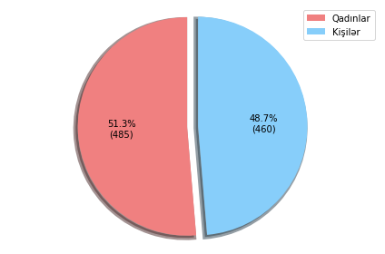

```python
gender_numbers = np.array([female_c,male_c])
mylabels = ["Qadınlar","Kişilər"]
colors = ['lightcoral', 'lightskyblue']
explode = (0.05, 0.05)
total = female_c + male_c
def myfunction(x):
  return '{:.1f}%\n({:.0f})'.format(x,round(total*x/100))

plt.pie(gender_numbers, explode=explode, autopct=myfunction, colors=colors, shadow=True, startangle=90, wedgeprops = {'linewidth': 5}, rotatelabels=True)
plt.legend(mylabels, loc="best")
plt.axis('equal')
plt.tight_layout()
plt.show()
```

**5. 51.3% qadınlar, 48.7% kişilər təşkil etdiyi və bu nisbətin dəyişməməsi üçün əlimizdə olan 55 cinsi məlum olmayan insanın cinslərini eyni nisbətdə bölürük və daha sonra yenə *pie chart* istifadə edərək nisbətin dəyişmədiyini görürük.**

```
 Təxmin olunmuş və siyahıya əlavə olunmuş qadınların sayı: 28
 Təxmin olunmuş və siyahıya əlavə olunmuş  kişilərin sayı: 27




 Cinsiyyətlə bağlı olan sütun emal olunduqdan sonraki vəziyyətinin vizual nisbəti:
```

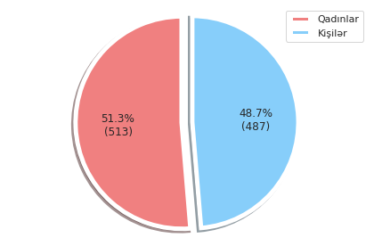

```python
def percentage_number(number, perc):
  return round((number*perc)/100)

unknown_female = percentage_number(unknown_c,female_percentage)
unknown_male = percentage_number(unknown_c,male_percentage)

print(" Təxmin olunmuş və siyahıya əlavə olunmuş qadınların sayı:",unknown_female,"\n","Təxmin olunmuş və siyahıya əlavə olunmuş  kişilərin sayı:",unknown_male)
print("\n","\n")
gender = DATA['gender'].fillna('Female', limit = unknown_female)
gender = gender.fillna('Male').to_numpy()

female_c = np.count_nonzero(gender == 'Female')
male_c = np.count_nonzero(gender == 'Male')

total = female_c + male_c
plt.pie(gender_numbers, explode=explode, autopct=myfunction, colors=colors, shadow=True, startangle=90, wedgeprops = {'linewidth': 5}, rotatelabels=True)
plt.legend(mylabels, loc="best")
plt.axis('equal')
plt.tight_layout()
print("\n","Cinsiyyətlə bağlı olan sütun emal olunduqdan sonraki vəziyyətinin vizual nisbəti:","\n")
plt.show()
```

**6. Cinsiyyətlə əlaqəli olan sütun bittikdən sonra yaşla bağlı sütuna keçirik. Bu sütunda isə yaş ortalamasının dəyişməməsi üçün bütün boş xanalara yaş sütünunun ümumi ortalamasını əlavə edirik. Faylı emal etdikdən sonra boş xanaların dolmağına baxmayaraq yaş ortalamasının dəyişmədiyini göstərmək üçün əvvəlcə ilkin variantına, daha sonra isə emal olunmuş variantına baxırıq.**

```python
print("Faylın ilkin formasında yaşlar:\n",DATA['age'].to_numpy(),"\n")
print("Faylın ilkin formasında yaş ortalaması:",DATA['age'].mean())
```

[output not shown]

```python
DATA['age'] = DATA['age'].fillna(DATA['age'].mean())
print("Faylın emal olunmuş formasında yaşlar:\n",DATA['age'].to_numpy(),"\n")
print("Faylın emal olunmuş formasında yaş ortalaması:",DATA['age'].mean())
```

```
Faylın emal olunmuş formasında yaşlar:
 [34.         32.         51.         43.         51.         39.
 41.49229188 37.         47.         23.         60.         30.
 49.         21.         60.         59.         40.         34.
 24.         35.         37.         51.         33.         41.49229188
 62.         28.         40.         58.         41.49229188 56.
 45.         43.         51.         41.49229188 34.         49.
 35.         33.         27.         37.         65.         36.
 30.         24.         33.         35.         25.         47.
 25.         41.         65.         58.         57.         21.
 61.         23.         47.         36.         37.         63.
 61.         44.         45.         32.         41.         32.
 48.         64.         31.         21.         18.         53.
 57.         49.         59.         57.         35.         37.
 28.         32.         25.         41.49229188 62.         51.
 44.         25.         46.         58.         34.         32.
 40.         26.         22.         20.         33.         58.
 31.         58.         57.         34.         37.         65.
 32.         43.         51.         59.         52.         39.
 34.         21.         30.         22.         19.         19.
 43.         59.         26.         57.         51.         41.49229188
 19.         33.         18.         37.         18.         53.
 39.         63.         19.         28.         42.         27.
 51.         30.         20.         26.         62.         47.
 23.         55.         60.         62.         24.         32.
 39.         37.         55.         29.         44.         53.
 37.         28.         25.         53.         40.         40.
 24.         43.         62.         29.         36.         39.
 47.         53.         40.         57.         57.         60.
 48.         19.         27.         38.         47.         53.
 24.         25.         22.         63.         41.         45.
 25.         20.         33.         52.         47.         41.
 43.         63.         41.49229188 34.         54.         28.
 51.         48.         21.         41.49229188 32.         19.
 28.         25.         47.         28.         40.         40.
 41.49229188 57.         28.         62.         39.         36.
 21.         42.         48.         57.         46.         43.
 50.         31.         23.         47.         28.         53.
 35.         42.         56.         29.         62.         18.
 50.         20.         41.         29.         31.         54.
```

[output cut: 115 more lines]

```
 54.         52.         44.         43.         59.         55.
 20.         63.         26.         58.         47.         54.
 40.         22.         21.         28.         26.         18.
 35.         49.         64.         59.         53.         64.
 49.         22.         52.         44.         43.         21.
 33.         21.         62.         43.         48.         61.
 53.         46.         61.         37.         48.         25.
 60.         62.         44.         48.         35.         19.
 47.         34.         42.         30.         38.         55.
 54.         62.         24.         54.         24.         61.
 49.         61.         37.         40.         33.         64.
 52.         37.         38.         24.         30.         53.
 43.         55.         65.         45.        ]

Faylın emal olunmuş formasında yaş ortalaması: 41.49229188078109
```

**7. Yaşları bu dərəcə çox decimalı olan float tipində göstərmək o qədər də əlverişli olmadığına görə boş xanalara doldurduğumuz yaşları yuvarlaqlaşdırırıq. Yuvarlaqlaşdırdıqdan sonra əvvəlki ortalama ilə böyük bir fərq olmadığını görürük. Deməli belə saxlaya bilərik. Qeyd edim ki, bütün objectləri numpy array-ə çevirməyimin səbəbi print etdikdə bütün elementlərin aydın görünməyini istəməyimdir.**

```python
age = round(DATA['age']).to_numpy()
print("Faylın son formasında yaşlar:\n",age,"\n")
print("Faylın son formasında yaş ortalaması:",age.mean())
```

[output not shown]

**8. Yaşlarla işimizi bitirdikdən sonra maaş sütununa gəlirik. Eynilə yaşı emal etdiyimiz yolla bu sütunu da emal edirik. Lakin buradakı fərq odur ki, maaş ortalamasını hesabladıqda bu sütunda olan dollar işarə bizə maneə törədəcək. Bu səbəbdən onu yox edirik, maaşları string tipindən float tipinə çeviririk və maaş ortalamasını hesablayırıq.**

```python
print("Faylın ilkin formasında maaşlar:\n",DATA['salary'].to_numpy(),"\n")
```

```
Faylın ilkin formasında maaşlar:
 ['$1272.21' '$4267.57' '$1941.82' '$4355.78' '$4588.28' '$2656.99'
 '$2937.16' '$1197.21' '$5204.16' '$1489.18' '$5352.69' '$2683.88'
 '$3545.32' '$3782.01' '$4248.56' nan '$3957.28' '$1130.16' '$2297.54'
 '$5489.38' '$2020.28' '$1142.42' '$2838.66' '$3603.14' '$3210.39'
 '$5279.36' '$1705.77' '$4231.14' '$5133.20' '$5073.84' '$4596.22'
 '$4202.64' '$5241.35' '$1230.55' '$4880.21' '$2228.15' '$4801.43'
 '$2766.37' '$2383.69' '$5250.87' '$3731.48' '$3860.11' nan '$4510.26'
 '$2649.99' '$4211.72' '$1726.46' '$4075.44' '$3006.26' '$1787.52'
 '$2126.84' '$3871.64' '$4538.56' '$4718.40' '$1387.45' '$1346.62'
 '$4977.38' '$2619.94' '$4690.28' '$5206.24' '$2163.61' '$3194.77'
 '$4510.41' '$1633.46' '$3130.45' '$4499.75' '$1106.03' '$2333.20'
 '$1114.34' '$2271.03' '$4352.62' '$1799.85' '$2770.10' '$2436.13'
 '$2212.45' '$2520.76' '$3616.03' '$2129.90' '$1965.43' '$1066.45'
 '$4350.39' '$1624.80' '$2169.87' '$3481.21' '$2217.66' '$1312.36'
 '$2239.73' '$3383.58' '$5170.82' '$3301.47' '$1281.43' '$2564.30'
 '$3768.92' '$2228.77' '$3131.54' '$1020.98' '$2618.73' '$4264.22'
 '$1577.93' '$3492.46' '$3448.33' '$3748.48' '$3431.90' '$5440.45'
 '$3108.59' '$4444.66' '$2486.63' '$2734.89' '$2804.21' '$1669.20'
 '$4222.09' '$3086.18' '$2536.22' '$4147.55' '$5230.31' '$4162.85'
 '$3452.70' '$1427.21' '$2240.54' '$4028.60' '$2843.63' '$2828.12'
 '$3701.69' '$5395.09' '$5413.29' '$5023.90' '$2789.38' '$1165.01'
 '$1103.61' '$3172.28' '$4700.47' '$1013.04' '$2241.01' nan '$4707.97'
 '$4877.07' '$4494.52' '$2633.25' '$1948.66' '$3140.36' '$3003.27'
 '$3694.20' '$2225.85' '$1162.97' '$3109.27' nan '$1711.69' '$4006.14'
 '$1158.79' '$3991.82' '$3854.49' '$4302.54' '$4768.16' '$2669.81'
 '$4520.48' '$4449.52' '$1189.61' '$3768.61' '$5133.58' '$3456.63'
 '$3246.91' '$4053.90' nan '$4258.01' '$3570.99' '$2672.10' '$2766.65'
 '$2991.78' '$1789.65' '$4656.52' '$1425.53' '$2434.48' '$4919.82'
 '$3683.51' '$3276.36' '$4574.20' '$5077.36' '$2879.85' '$4109.04'
 '$5345.24' '$3908.18' '$2393.80' '$3544.82' '$1017.35' nan '$2476.12'
 '$4849.65' '$2111.04' '$5374.39' '$1230.67' '$3864.45' '$1881.20'
 '$3581.24' '$1166.40' '$4177.91' '$5003.43' '$3703.90' nan '$4528.92'
 '$1040.31' '$3777.21' '$3128.71' '$3094.67' '$2809.14' '$4263.74'
 '$2253.19' '$2037.98' '$1582.21' '$4494.88' '$1605.43' '$2077.89'
 '$3947.42' '$1406.86' '$2067.05' '$3639.87' '$4981.37' '$1738.89'
 '$3650.29' '$4444.94' '$2050.53' '$4170.16' '$4737.85' '$5139.73'
 '$4454.21' '$5426.89' '$4216.18' '$2077.79' '$3552.73' '$3087.29'
 '$2264.00' '$4614.14' '$1742.26' '$3088.89' '$1401.64' nan '$2523.20'
 '$2878.79' '$1219.10' '$1028.31' nan '$4181.76' '$1413.59' '$3439.35'
```

[output cut: 106 more lines]

```
 '$2792.52' '$1123.94' '$5363.18' nan '$2870.86' '$4697.81' '$4284.60'
 '$5248.81' '$5267.22' '$2477.27' '$1173.35' '$5019.25' '$4327.74'
 '$3579.87' '$3999.65' nan '$2487.01' '$3390.74' '$4264.35' '$2369.41'
 '$3492.79' '$4871.95' '$4137.16' '$3760.53' '$4469.89' '$2838.69'
 '$3490.85' '$2938.24' '$4530.31' '$3398.92' '$1854.20' nan '$2557.29'
 '$3965.43' '$2774.48' '$3563.56' '$3519.16' '$1064.93' '$5331.81'
 '$2921.85' '$5015.74' '$3683.94' '$4498.23' '$2882.24' '$2574.04'
 '$1165.16' nan nan '$2049.03' '$5193.46' '$5030.47' '$4344.71' '$5307.01'
 '$2629.81' '$1178.62' '$4754.92' '$2797.12' '$1614.21' '$5316.48'
 '$1142.26' '$3492.94' '$4926.67' '$2644.30' '$2178.10' nan '$3812.00'
 '$3941.47' '$1107.92' '$5240.52' '$1539.40' '$4906.90' '$4621.58'
 '$2153.57' '$3064.10' '$3363.18' nan '$4396.40' '$2966.29' '$1816.26' nan
 '$5341.56' '$3844.93' '$2362.30' '$4446.86' nan '$1555.09' '$1861.51'
 '$5496.19' '$4133.49' '$1698.39' '$2230.41' '$2073.04' '$2082.49'
 '$2439.44']
```

```python
DATA['salary'] = DATA['salary'].replace({'\$': ''}, regex=True)
salary = DATA['salary'].to_numpy()
salary = salary.astype(np.float)
salary = pd.Series(salary)

print("Faylın ilkin formasında maaş ortalaması:",salary.mean())
```

```
Faylın ilkin formasında maaş ortalaması: 3206.955445026181
```

```python
salary = salary.fillna(salary.mean())
print("Faylın emal olunmuş formasında maaşlar:\n",salary.to_numpy(),"\n")
print("Faylın emal olunmuş formasında maaş ortalaması:",salary.mean())
```

```
Faylın emal olunmuş formasında maaşlar:
 [1272.21       4267.57       1941.82       4355.78       4588.28
 2656.99       2937.16       1197.21       5204.16       1489.18
 5352.69       2683.88       3545.32       3782.01       4248.56
 3206.95544503 3957.28       1130.16       2297.54       5489.38
 2020.28       1142.42       2838.66       3603.14       3210.39
 5279.36       1705.77       4231.14       5133.2        5073.84
 4596.22       4202.64       5241.35       1230.55       4880.21
 2228.15       4801.43       2766.37       2383.69       5250.87
 3731.48       3860.11       3206.95544503 4510.26       2649.99
 4211.72       1726.46       4075.44       3006.26       1787.52
 2126.84       3871.64       4538.56       4718.4        1387.45
 1346.62       4977.38       2619.94       4690.28       5206.24
 2163.61       3194.77       4510.41       1633.46       3130.45
 4499.75       1106.03       2333.2        1114.34       2271.03
 4352.62       1799.85       2770.1        2436.13       2212.45
 2520.76       3616.03       2129.9        1965.43       1066.45
 4350.39       1624.8        2169.87       3481.21       2217.66
 1312.36       2239.73       3383.58       5170.82       3301.47
 1281.43       2564.3        3768.92       2228.77       3131.54
 1020.98       2618.73       4264.22       1577.93       3492.46
 3448.33       3748.48       3431.9        5440.45       3108.59
 4444.66       2486.63       2734.89       2804.21       1669.2
 4222.09       3086.18       2536.22       4147.55       5230.31
 4162.85       3452.7        1427.21       2240.54       4028.6
 2843.63       2828.12       3701.69       5395.09       5413.29
 5023.9        2789.38       1165.01       1103.61       3172.28
 4700.47       1013.04       2241.01       3206.95544503 4707.97
 4877.07       4494.52       2633.25       1948.66       3140.36
 3003.27       3694.2        2225.85       1162.97       3109.27
 3206.95544503 1711.69       4006.14       1158.79       3991.82
 3854.49       4302.54       4768.16       2669.81       4520.48
 4449.52       1189.61       3768.61       5133.58       3456.63
 3246.91       4053.9        3206.95544503 4258.01       3570.99
 2672.1        2766.65       2991.78       1789.65       4656.52
 1425.53       2434.48       4919.82       3683.51       3276.36
 4574.2        5077.36       2879.85       4109.04       5345.24
 3908.18       2393.8        3544.82       1017.35       3206.95544503
 2476.12       4849.65       2111.04       5374.39       1230.67
 3864.45       1881.2        3581.24       1166.4        4177.91
```

[output cut: 148 more lines]

```
 3398.92       1854.2        3206.95544503 2557.29       3965.43
 2774.48       3563.56       3519.16       1064.93       5331.81
 2921.85       5015.74       3683.94       4498.23       2882.24
 2574.04       1165.16       3206.95544503 3206.95544503 2049.03
 5193.46       5030.47       4344.71       5307.01       2629.81
 1178.62       4754.92       2797.12       1614.21       5316.48
 1142.26       3492.94       4926.67       2644.3        2178.1
 3206.95544503 3812.         3941.47       1107.92       5240.52
 1539.4        4906.9        4621.58       2153.57       3064.1
 3363.18       3206.95544503 4396.4        2966.29       1816.26
 3206.95544503 5341.56       3844.93       2362.3        4446.86
 3206.95544503 1555.09       1861.51       5496.19       4133.49
 1698.39       2230.41       2073.04       2082.49       2439.44      ]

Faylın emal olunmuş formasında maaş ortalaması: 3206.9554450261817
```

**9. Bütün maaşlar iki decimallı float tipində olduğuna görə boşluqlara qoyduğumuz maaşları da iki decimala çeviririk və ümumi maaş ortalamasını bir daha hesablayırıq. Ortalamada böyük bir fərq olmadığına görə belə saxlaya bilərik.**

```python
salary = round(salary,2).to_numpy()
print("Faylın son formasında maaşlar:\n",np.sort(salary, axis=None),"\n")
print("Faylın son formasında maaş ortalaması:",salary.mean())
```

```
Faylın son formasında maaşlar:
 [1005.87 1011.4  1013.04 1014.62 1017.35 1020.98 1021.67 1022.46 1028.31
 1032.27 1033.3  1035.29 1040.31 1048.1  1053.8  1055.74 1062.07 1064.93
 1066.12 1066.2  1066.45 1085.7  1086.94 1093.35 1093.39 1103.61 1106.03
 1107.16 1107.92 1110.46 1112.53 1114.34 1120.4  1120.49 1123.94 1126.97
 1130.16 1130.56 1131.55 1132.48 1142.26 1142.42 1153.21 1154.22 1158.79
 1162.97 1165.01 1165.16 1166.4  1168.54 1173.35 1176.67 1178.62 1189.61
 1190.1  1197.21 1200.83 1210.38 1214.95 1216.9  1219.1  1226.9  1230.55
 1230.67 1261.01 1261.18 1268.92 1269.67 1272.16 1272.21 1278.83 1281.43
 1291.94 1293.09 1296.05 1296.32 1304.93 1307.2  1312.36 1313.34 1314.65
 1318.18 1326.2  1333.41 1342.67 1343.58 1346.62 1349.63 1358.75 1371.73
 1372.54 1373.04 1377.28 1380.18 1386.82 1387.45 1401.64 1406.86 1413.59
 1421.03 1423.89 1425.53 1427.21 1434.58 1437.95 1444.13 1446.82 1449.03
 1467.73 1471.58 1472.18 1473.64 1480.67 1489.18 1492.87 1498.77 1523.11
 1526.9  1539.4  1541.52 1552.32 1555.09 1572.92 1577.9  1577.93 1582.21
 1589.78 1591.62 1605.43 1613.98 1614.21 1618.63 1624.8  1629.08 1632.12
 1633.46 1649.99 1650.87 1652.58 1653.71 1656.28 1657.5  1669.2  1672.41
 1673.95 1675.76 1678.64 1680.25 1687.83 1694.1  1694.72 1695.3  1698.39
 1703.19 1705.77 1711.69 1712.61 1718.23 1721.14 1724.44 1726.46 1731.36
 1738.89 1741.09 1742.26 1742.44 1751.96 1758.08 1759.78 1766.56 1775.01
 1776.26 1787.21 1787.52 1789.2  1789.65 1799.85 1811.84 1815.81 1816.26
 1818.63 1818.96 1824.78 1836.41 1838.16 1838.51 1840.36 1844.94 1854.2
 1856.71 1860.69 1860.8  1861.51 1869.09 1877.74 1881.2  1881.97 1882.25
 1888.87 1891.63 1895.34 1904.75 1909.79 1918.07 1920.75 1920.99 1941.82
 1948.41 1948.66 1965.42 1965.43 1973.58 1984.39 1988.13 2005.61 2007.33
 2013.67 2020.28 2022.5  2033.49 2037.98 2049.03 2050.53 2053.64 2067.05
 2073.04 2077.79 2077.89 2078.44 2082.49 2083.09 2084.4  2085.48 2097.66
 2110.9  2111.04 2112.99 2116.23 2117.01 2122.5  2125.62 2126.84 2128.26
 2129.9  2135.5  2146.08 2148.47 2153.57 2157.22 2163.61 2167.62 2169.87
 2173.14 2177.38 2178.1  2182.21 2184.77 2199.11 2199.67 2210.84 2212.45
 2217.66 2225.85 2228.15 2228.77 2228.97 2229.87 2230.41 2239.73 2240.54
 2241.01 2244.28 2253.19 2256.22 2259.95 2264.   2265.36 2269.49 2271.03
 2273.83 2274.63 2297.54 2307.47 2316.08 2327.31 2333.2  2339.5  2351.74
 2362.3  2369.41 2371.64 2375.73 2379.79 2383.69 2387.45 2388.44 2393.8
 2398.23 2400.16 2402.26 2404.24 2408.38 2408.6  2426.91 2429.83 2432.73
 2434.48 2436.13 2439.44 2450.14 2468.38 2474.06 2476.12 2477.27 2477.87
 2479.88 2480.   2483.06 2486.63 2487.01 2490.79 2504.71 2507.39 2511.42
 2512.55 2519.03 2520.76 2523.2  2533.41 2536.22 2542.69 2545.67 2549.51
 2557.22 2557.29 2561.   2564.3  2566.45 2566.9  2569.53 2570.66 2574.04
 2577.41 2577.58 2578.59 2609.39 2611.06 2618.73 2619.94 2624.39 2625.04
```

[output cut: 60 more lines]

```
 5003.43 5015.74 5015.94 5019.25 5023.9  5024.64 5030.47 5043.84 5047.72
 5052.37 5058.18 5066.73 5073.84 5077.36 5078.02 5088.17 5099.34 5118.97
 5119.18 5120.58 5128.16 5131.14 5133.14 5133.2  5133.58 5139.73 5146.19
 5147.06 5154.4  5154.43 5163.03 5168.03 5170.82 5174.63 5183.99 5187.03
 5189.94 5193.46 5196.24 5196.61 5201.25 5201.41 5204.16 5204.54 5206.24
 5208.15 5218.07 5220.82 5221.74 5226.99 5230.31 5234.73 5236.39 5240.25
 5240.52 5241.35 5248.81 5250.87 5255.68 5258.32 5260.04 5265.61 5267.22
 5273.44 5279.22 5279.36 5294.54 5300.85 5305.03 5307.01 5316.48 5322.74
 5323.06 5327.   5331.81 5337.74 5339.83 5341.51 5341.56 5345.24 5351.08
 5352.69 5363.18 5363.43 5367.6  5367.67 5367.95 5369.72 5374.39 5395.09
 5399.35 5408.16 5412.81 5413.29 5426.89 5431.41 5432.23 5432.33 5433.24
 5439.06 5440.45 5453.79 5456.25 5460.07 5461.05 5475.13 5489.38 5496.19
 5498.91]

Faylın son formasında maaş ortalaması: 3206.9556500000003
```

**10. Purchased sütununu predict etmək üçün isə *Pandas* kitabxanasının interpolate() funksiyasının pad metodundan istifadə edirik. Bu funksiya proqnozlaşdırmaq üçün çox güclü funksiyadır və müxtəlif metodları var. Biz pad metodunu seçtik, çünki əlimizdə olan DATA-ya ən uyğun olan metod o idi. Əslində digər sütunların təxmin edilməsində də eyni funksiyanın müxtəlif metodlarından oluna bilərdi. Lakin bir çox yolla yanaşmaq istədik.**

```python
purchased = DATA['purchased'].interpolate(method='pad').to_numpy()
print("Funksiyadan istifadə edərək proqnozlaşdırdıqdan sonra əldə etdiyimiz məlumatlar:\n",purchased)
```

```
Funksiyadan istifadə edərək proqnozlaşdırdıqdan sonra əldə etdiyimiz məlumatlar:
 [False False  True False  True False False  True  True  True False  True
  True  True  True  True False False  True False  True False False  True
 False False  True False False  True  True  True  True  True  True False
  True  True False  True False False  True False  True  True False  True
  True  True False  True  True  True False  True False  True False  True
  True False  True False  True False False False False False False  True
 False False False  True  True False False False  True False  True  True
 False False False  True  True  True  True False  True  True False False
 False False False False False  True  True False False False  True False
 False  True False  True  True False  True False  True  True  True  True
 False  True  True False False False False  True  True False False  True
 False False  True  True  True  True  True False  True False  True False
  True  True  True  True  True  True  True  True  True  True  True  True
  True False  True False False False False False False  True  True  True
  True False  True  True False False  True  True False False False False
  True False False False False False False  True  True  True  True False
 False False False False  True  True False  True  True  True  True  True
  True  True  True False  True  True False  True False  True  True False
 False  True False  True False False False  True False  True  True  True
 False False  True False  True  True  True False  True  True False False
 False False False  True False  True  True  True  True False False False
  True  True  True  True  True  True  True False False False False False
  True False  True  True False False False False  True False  True  True
 False False  True  True False False False  True False False  True False
 False False False False  True False  True False  True False False False
  True False False False False False False  True  True  True False False
 False  True  True False  True False  True False False  True  True  True
 False False  True False  True  True  True  True False False False False
  True False False False False  True  True  True  True  True  True  True
 False False False False  True  True False  True False False  True False
  True  True  True False False  True False False  True False  True  True
  True  True False False  True False  True False False False  True  True
 False  True False  True  True  True False  True  True  True  True False
  True False  True  True False False False False False False  True  True
  True  True False  True  True  True False  True  True False  True False
 False False False False False False  True False  True False False  True
 False False False  True False  True  True  True  True False  True  True
  True False  True  True False  True False False  True False False False
 False False False  True  True False  True  True  True False  True  True
```

[output cut: 30 more lines]

```
  True  True  True False  True False False False  True  True  True False
 False False  True  True False False False  True False  True False  True
 False  True  True  True  True False False  True  True False False  True
 False False False  True False False  True False False  True  True False
 False  True  True False  True  True  True  True  True  True  True  True
  True False False  True False False  True  True  True False False  True
 False False False False  True False False  True False False  True  True
  True  True  True False False  True False False  True  True  True False
 False False False False False False False  True  True False False False
  True  True  True False False False False  True  True  True  True  True
 False  True  True False  True  True  True  True  True False False False
 False False False False False  True False  True  True  True  True  True
  True False False  True  True  True  True False False  True False  True
  True False  True False  True False False  True  True False  True False
 False False  True False]
```

**11. IP adreslərinin təkrarlanmadığına (yəni eyni müştəridən bir neçə dənə olmadığına və silməyə ehtiyac olmadığına) əmin olmaq üçün *pandas* kitabxanasının duplicate() funksiyasından istifadə edirik. Və nəticədə bütün dolu xanalarda False alırıq, yəni siyahıda təkrarlanan müştəri yoxdur. Davam edə bilərik.**

```python
Duplicated = DATA.duplicated(subset='ip_adress')
print(Duplicated)
```

```
0      False
1      False
2      False
3      False
4      False
       ...
995    False
996    False
997    False
998    False
999    False
Length: 1000, dtype: bool
```

**12. IP adresləri unique olduğundan onu təxmin edə bilmərik deyə düşünürük. Və DATA-nı visualize edəndə biz digər sütünlardan istifadə edəcəyik. DATA-mız səliqəli olsun deyə IP adresləri bilinməyən müştərilərin IP adresi olan sütundaki sıralarına "unknown" yazırıq.**

```python
ip_adress = DATA['ip_adress'].fillna('unknown').to_numpy()
print("Bilinməyən şəxslər üçün 'unknown' əlavə etdikdən sonra əldə etdiyimiz array:\n",ip_adress)
```

```
Bilinməyən şəxslər üçün 'unknown' əlavə etdikdən sonra əldə etdiyimiz array:
 ['148.43.31.222/2' '108.5.220.226/24' '23.130.62.192/7' '21.137.90.224/12'
 '243.20.242.45/21' '17.13.211.105/29' 'unknown' '190.185.18.109/4'
 '34.96.111.231/16' '98.72.88.149/11' '63.74.43.163/26'
 '227.196.164.230/9' '206.94.6.208/27' '172.163.129.204/12'
 '197.32.144.56/23' '181.67.179.168/2' '33.35.85.74/13'
 '138.245.94.111/27' '142.118.167.6/8' '192.195.191.134/22'
 '224.147.107.97/27' '123.153.95.230/31' '94.166.67.242/9' 'unknown'
 '63.116.221.118/8' '136.241.213.208/9' '115.124.65.239/18'
 '217.19.190.203/23' 'unknown' '2.104.226.68/9' '239.41.239.190/24'
 '235.191.100.232/9' '250.223.87.64/27' 'unknown' '251.132.37.10/15'
 '36.170.233.137/9' '171.49.208.8/1' '156.68.242.165/21' '77.207.116.11/1'
 '158.169.135.233/4' '93.23.130.151/20' '18.20.243.164/4' '84.2.40.189/22'
 '75.26.194.9/12' '233.33.131.207/1' '63.254.171.118/1'
 '194.185.147.140/22' '254.93.69.244/17' '123.28.192.184/14'
 '128.109.164.248/23' '229.58.235.94/10' '140.167.212.121/16'
 '185.243.94.14/17' '46.229.42.180/11' '75.229.116.9/31'
 '184.240.230.160/26' '77.120.71.28/8' '238.240.161.44/14'
 '167.210.236.116/20' '240.36.73.57/8' '202.211.89.17/26'
 '113.146.141.53/1' '52.20.9.183/17' '124.117.43.193/6'
 '147.250.135.223/17' '182.99.219.88/18' '49.194.109.180/23'
 '129.209.248.73/23' '117.56.36.36/28' '194.171.13.163/5'
 '229.106.57.136/6' '47.165.178.60/16' '121.134.44.153/26'
 '79.161.101.60/13' '29.10.48.235/6' '133.223.5.199/25' '70.3.16.45/16'
 '234.220.154.129/28' '127.113.7.208/19' '133.52.172.135/15'
 '174.117.226.88/3' 'unknown' '228.30.177.170/5' '59.193.72.35/9'
 '240.204.5.228/15' '233.21.95.84/23' '190.183.90.227/6'
 '22.165.142.140/25' '101.49.228.57/10' '103.211.93.136/19'
 '41.109.193.196/17' '191.47.43.207/29' '209.66.127.185/19'
 '226.162.151.83/30' '224.26.25.78/26' '84.158.191.4/23' '149.59.99.96/25'
 '210.69.99.60/21' '76.160.132.211/13' '207.115.139.55/8'
 '39.22.132.156/24' '137.59.235.243/8' '187.140.108.204/10'
 '25.197.221.56/2' '173.145.206.82/9' '187.182.230.213/16'
 '79.219.176.160/7' '191.139.106.130/1' '90.34.109.234/17'
 '22.42.50.145/5' '97.67.176.106/14' '118.13.90.162/16' '76.109.62.228/15'
 '57.101.12.242/29' '28.105.48.227/16' '177.63.37.140/22' '3.59.30.140/30'
 '162.206.104.245/3' '100.39.41.151/17' 'unknown' '32.221.20.111/22'
 '12.124.139.231/1' '47.70.104.54/25' '139.135.113.241/29'
 '177.165.31.33/22' '60.200.140.217/17' '217.75.56.25/1'
 '51.242.66.239/12' '101.216.164.93/24' '197.81.65.78/16'
```

[output cut: 250 more lines]

```
 '228.3.65.201/18' '130.145.202.228/21' '9.166.122.129/7'
 '60.127.101.6/17' '96.89.72.95/6' '124.34.238.183/21'
 '220.220.236.216/22' '253.6.253.202/27' '197.66.161.39/27'
 '56.95.94.93/6' '9.145.116.102/8' '252.64.77.196/26' '213.198.128.124/30'
 '228.103.254.123/13' '136.3.190.90/1' '209.170.222.42/8'
 '162.8.167.162/23' '227.226.215.66/16' '242.139.168.51/8'
 '224.35.242.42/7' '31.7.106.230/12' '198.224.202.154/2' '59.21.65.64/12'
 '27.59.106.57/1' '98.108.226.211/12' '46.85.64.112/22' '110.124.16.89/19'
 '31.49.162.158/11' '62.222.208.119/31' '6.27.115.201/19'
 '37.121.142.68/31' '194.12.85.158/24' '118.131.158.90/18'
 '185.144.196.123/17' '180.13.94.76/8' '196.187.244.102/9'
 '62.26.47.102/12' '12.7.195.29/6' '80.119.30.72/25' '11.100.148.234/13'
 '118.120.220.20/6' '54.131.188.51/28' '8.78.110.126/6'
 '162.161.23.214/28' '203.216.44.175/30' '129.229.17.8/13'
 '52.225.119.89/26' '134.143.187.185/19']
```

**13. Nəhayət əlimizdə olan bütün sütünları təmizlədikdən və emal etdikdən sonra DATA-mızı strukturlaşdıra bilərik.**

```python
gender = pd.Series(gender)
age = pd.Series(age)
salary = pd.Series(salary)
purchased = pd.Series(purchased)
ip_adress = pd.Series(ip_adress)


DATA['gender'] = gender
DATA['age'] = age
DATA['salary'] = salary
DATA['purchased'] = purchased
DATA['ip_adress'] = ip_adress

print("Emaldan sonra aldığımız Data Frame:\n",DATA.head(20)) #1000 sıra çap etmək əlverişsiz olar, ona görə göstərmək üçün 20 sıra çap edirik
```

```
Emaldan sonra aldığımız Data Frame:
     id           ip_adress  gender   age   salary  purchased
0    1     148.43.31.222/2    Male  34.0  1272.21      False
1    2    108.5.220.226/24  Female  32.0  4267.57      False
2    3     23.130.62.192/7  Female  51.0  1941.82       True
3    4    21.137.90.224/12    Male  43.0  4355.78      False
4    5    243.20.242.45/21    Male  51.0  4588.28       True
5    6    17.13.211.105/29  Female  39.0  2656.99      False
6    7             unknown  Female  41.0  2937.16      False
7    8    190.185.18.109/4    Male  37.0  1197.21       True
8    9    34.96.111.231/16  Female  47.0  5204.16       True
9   10     98.72.88.149/11  Female  23.0  1489.18       True
10  11     63.74.43.163/26  Female  60.0  5352.69      False
11  12   227.196.164.230/9    Male  30.0  2683.88       True
12  13     206.94.6.208/27  Female  49.0  3545.32       True
13  14  172.163.129.204/12    Male  21.0  3782.01       True
14  15    197.32.144.56/23    Male  60.0  4248.56       True
15  16    181.67.179.168/2  Female  59.0  3206.96       True
16  17      33.35.85.74/13    Male  40.0  3957.28      False
17  18   138.245.94.111/27    Male  34.0  1130.16      False
18  19     142.118.167.6/8  Female  24.0  2297.54       True
19  20  192.195.191.134/22    Male  35.0  5489.38      False
```

**13. Bu DATA FRAME-i daha strukturlu formada göstərmək üçün ayrı-ayrılıqda həm maaşa görə, həm də yaşa görə sort edə bilərik.**

```python
column_names_1=['ip_adress','gender', 'age', 'salary','purchased']


DATA_structured = pd.DataFrame(columns = column_names_1)
DATA_structured['gender'] = gender
DATA_structured['age'] = age
DATA_structured['salary'] = salary
DATA_structured['purchased'] = purchased
DATA_structured['ip_adress'] = ip_adress
```

**YAŞA GÖRƏ ARTAN SIRALAMA:**

```python
DATA_age = DATA_structured.sort_values('age')
print("Yaşa görə artan sıralasaq:\n",DATA_age.head(20))
```

```
Yaşa görə artan sıralasaq:
               ip_adress  gender   age   salary  purchased
381   15.210.245.252/17  Female  18.0  1577.90      False
124    177.165.31.33/22  Female  18.0  5413.29      False
781   84.250.124.241/30    Male  18.0  5196.24      False
122     47.70.104.54/25  Female  18.0  3701.69       True
844       8.66.93.204/2  Female  18.0  2402.26      False
374      11.78.7.217/20    Male  18.0  4203.93      False
70     229.106.57.136/6  Female  18.0  4352.62      False
941    55.224.126.12/17    Male  18.0  3563.56      False
668  116.172.205.118/25    Male  18.0  3869.45       True
661   126.165.232.104/1    Male  18.0  4998.06       True
319   184.213.105.244/7  Female  18.0  3799.88      False
852    155.30.141.88/26  Female  18.0  3928.47      False
336     96.122.171.58/1  Female  18.0  4800.49       True
439   179.130.227.253/6    Male  18.0  5187.03       True
227    118.79.27.223/26    Male  18.0  3552.73       True
545    190.173.82.224/4  Female  18.0  4474.90       True
457    161.195.171.55/9  Female  19.0  4881.85      False
690   238.125.192.161/6  Female  19.0  1860.69      False
197      4.133.69.81/25  Female  19.0  3206.96       True
644      96.13.107.73/2  Female  19.0  5204.54      False
```

**MAAAŞA GÖRƏ ARTAN SIRALAMA:**

```python
DATA_salary = DATA_structured.sort_values('salary')
print("Maaşa görə artan sıralasaq:\n",DATA_salary.head(20))
```

```
Maaşa görə artan sıralasaq:
               ip_adress  gender   age   salary  purchased
413    13.66.136.181/20  Female  51.0  1005.87       True
447  195.212.115.254/25    Male  39.0  1011.40       True
131   244.244.122.116/7  Female  27.0  1013.04       True
812  178.239.206.183/15    Male  30.0  1014.62       True
183     57.242.85.27/16    Male  52.0  1017.35      False
95      84.158.191.4/23  Female  58.0  1020.98      False
263   242.116.119.85/18  Female  64.0  1021.67      False
362     217.171.56.50/9  Female  49.0  1022.46       True
238    151.246.194.90/1  Female  27.0  1028.31      False
574     8.66.141.214/15  Female  56.0  1032.27       True
669    94.182.179.138/7    Male  47.0  1033.30      False
850     19.79.221.34/10  Female  32.0  1035.29      False
199   232.185.129.240/6    Male  25.0  1040.31       True
306   109.43.161.167/14    Male  27.0  1048.10      False
784    123.72.102.166/9  Female  26.0  1053.80      False
510  246.126.214.127/30  Female  31.0  1055.74      False
530    80.73.251.112/19    Male  44.0  1062.07      False
943    54.232.102.192/9    Male  49.0  1064.93       True
552   19.199.128.204/15    Male  22.0  1066.12      False
689    28.251.37.121/30  Female  51.0  1066.20      False
```

**14. İndi isə emal olunmuş DATA-mızdan istifadə edərək vizuallaşdıra bilərik.**

```
 Müştərilərin cinsiyyət faiz nisbəti:
```

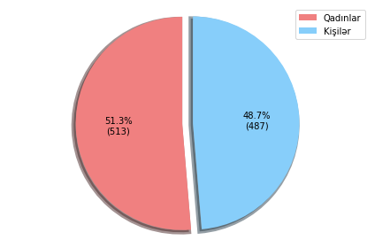

```python
plt.pie(gender_numbers, explode=explode, autopct=myfunction, colors=colors, shadow=True, startangle=90, wedgeprops = {'linewidth': 5}, rotatelabels=True)
plt.legend(mylabels, loc="best")
plt.axis('equal')
plt.tight_layout()
print("\n","Müştərilərin cinsiyyət faiz nisbəti:","\n")
plt.show()
```

## **⬆Gördüyümüz kimi müştərilərimiz arasında qadınlar üstünlük təşkil edir.**

```
Müştərilərin hər yaş sayının cinsdən asılılığı (Narıncı Qadınlar, Mavi Kişilər):
```

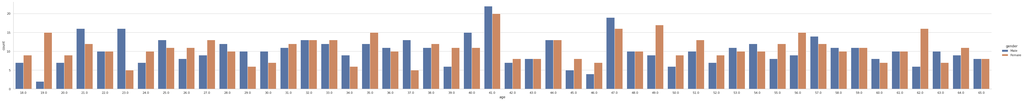

```python
print("Müştərilərin hər yaş sayının cinsdən asılılığı (Narıncı Qadınlar, Mavi Kişilər):\n")
plt.figure(figsize=(26, 13))
sns.catplot(x='age',kind="count",hue='gender',height=5, aspect=10, data=DATA)
#plt.xlim(18,30)
```

## **⬆Seaborn kitabxanasının köməyə ilə çəkdiyimiz bu plotdan da müştərilərin hər yaşının cinsdən asılılığını görə bilərik. Məlumat çox olduğundan plt.xlim() vasitəsilə istədiyimiz aralığı yaxınlaşdırıb baxmaq olar.**

```
Müştərilərin yaşının məhsulu almaqdan asılılığı (Göy almayanlar, narıncı alanlar):
```

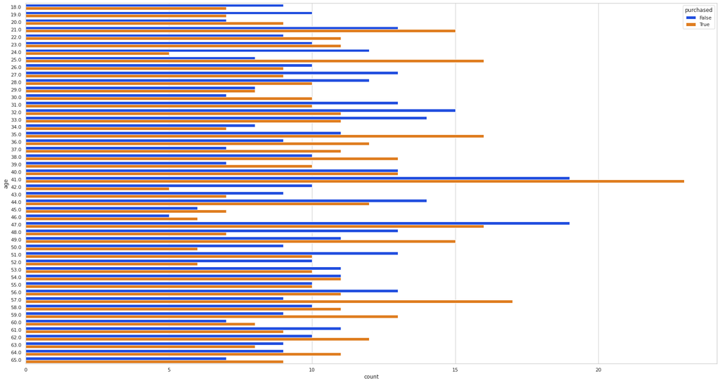

```python
print("Müştərilərin yaşının məhsulu almaqdan asılılığı (Göy almayanlar, narıncı alanlar):\n")
plt.figure(figsize=(28, 15))
sns.countplot(y="age", hue="purchased", data=DATA, palette="bright")
```

## **⬆Yenə Seaborn kitabxanasının köməyə ilə çəkdiyimiz bu plotdan müştərilərin hər yaşının məhsulu alıb-almamaqdan asılılığını görə bilərik. Qrafikdən də məlum olduğu kimi məhsulu ən çox alan yaş 41 yaşdır. Buna səbəb ortalama yaşın 41 olmağı ola bilər. Məlumat çox olduğundan plt.ylim() vasitəsilə istədiyimiz aralığı yaxınlaşdırıb baxmaq olar.**

```
Müştərilərin cinsinin məhsulu almaqdan asılılığı (Narıncı almayanlar, yaşıl alanlar):
```

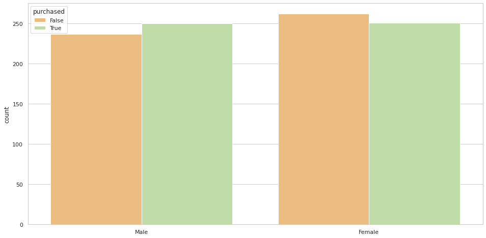

```python
print("Müştərilərin cinsinin məhsulu almaqdan asılılığı (Narıncı almayanlar, yaşıl alanlar):\n")
plt.figure(figsize=(16, 8))
sns.countplot(x=gender, hue="purchased", data=DATA, palette="Spectral")
```

## **⬆Bu plotdan isə müştərilərin cinsinin məhsulu alıb-almamaqdan asılılığını görə bilərik. Qrafikdən də məlum olduğu kimi qadın almayanların sayı üstünlük təşkil edir. Buna səbəb qadınların sayının çox olmağı ola bilər. Lakin alanların sayı hər iki cinsdə çox yaxındır.**

**15. Və nəhayət, əgər istəsək emal olunmuş DATA-mızı export edə bilərik.**

```python
#DATA = DATA.to_csv(r'Export etmək istədiyimiz yol (path)\DATA_final.csv')
```